# Problem Set 5

Your Name Here

Due October 23, 2026

In this problem set we will use the did_ps5.RDS dataset which is available on Canvas.

You are working for the governor of Ohio, the year is 2025. In the last few years, crime levels have unfortunately been unusually high. In response to this, the governor just implemented a series of policies designed to bring crime rates back down. The policies will roll out in early 2026, so that is the earliest they could have an impact.

**For each regression in this problem set, be sure to display coefficient estimates by running summary(model_name)$coefficients at the end of the code chunk**

Your job is to show quantitatively whether those policies were effective. You have data from municipalities in Ohio (coded as state==1) as well as 19 other states.

```r
packages = c("tidyverse","plm","ggplot2")

#this function checks if you have the necessary packages
#if you have them it loads them, if you don't it installs and loads them
package.check <- lapply(packages, FUN = function(x) {
  if (!require(x, character.only = TRUE)) {
    install.packages(x, dependencies = TRUE)
    library(x, character.only = TRUE)
  }
})
```

First, load the data and create the variables you will need to run the standard DiD specification:

$Y_{st} = Treat_s + Post_t + Treat_s*Post_t$

```r
ps_data <- readRDS("../data/ps5_did.rds")

ps_data <- ps_data |>
  mutate(
    Treat_s = ifelse(state == 1, TRUE, FALSE),
    Post_t = ifelse(year >= 2026, TRUE, FALSE),
  )

glimpse(ps_data)
```

```
## Rows: 100,000
## Columns: 5
## $ Y       <dbl> 13.199815, 8.795446, 12.927355, 10.813655, 9.946388, 9.468094,…
## $ year    <int> 2024, 2024, 2026, 2029, 2022, 2024, 2029, 2023, 2022, 2029, 20…
## $ state   <int> 1, 1, 1, 1, 1, 1, 1, 1, 1, 1, 1, 1, 1, 1, 1, 1, 1, 1, 1, 1, 1,…
## $ Treat_s <lgl> TRUE, TRUE, TRUE, TRUE, TRUE, TRUE, TRUE, TRUE, TRUE, TRUE, TR…
## $ Post_t  <lgl> FALSE, FALSE, TRUE, TRUE, FALSE, FALSE, TRUE, FALSE, FALSE, TR…
```

Now run the specification and display the coefficient estimates

```r
did_specification <- lm(Y ~ Treat_s + Post_t + (Treat_s*Post_t),
                        data = ps_data)

summary(did_specification)$coefficients
```

```
##                          Estimate  Std. Error     t value      Pr(>|t|)
## (Intercept)            10.8486527 0.008881264 1221.521309  0.000000e+00
## Treat_sTRUE            -0.8892225 0.039774048  -22.356852 1.934887e-110
## Post_tTRUE              1.9884169 0.012588034  157.960875  0.000000e+00
## Treat_sTRUE:Post_tTRUE -0.4014360 0.056802087   -7.067275  1.590333e-12
```

Now, run the Two-Way Fixed Effects (TWFE version):

$Y_{st} = \gamma_t + \delta_s + Treat_s*Post_t$

Where $\gamma_t$ and $\delta_s$ are year and state fixed effects, respectively.

Hint: look at the regressions from PS4 for an example of how to add state and year fixed effects.

```r
twfe_specification <- plm(Y ~ Treat_s + Post_t + (Treat_s*Post_t),
                          data = ps_data,
                          index = c("state", "year"),
                          model = "within",
                          effect = "twoways")

summary(twfe_specification)$coefficients
```

```
##                          Estimate Std. Error   t-value     Pr(>|t|)
## Treat_sTRUE:Post_tTRUE -0.4081672 0.04381179 -9.316376 1.227224e-20
```

Are the coefficients different? Are they about the same? Why are they not identical?

**The coefficients are very similar but slightly different (-0.4014360 vs. -0.408167). This is because the TWFE model incorporates year and state fixed effects, so it removes state and time differences that can appear in the DiD model. This is mostly seen through the different number of states observed across time, which leads to our difference in coefficient estimates here.**

You want to be sure the DiD worked correctly, so manually calculate the DiD using the four conditional means

```r
did_manual <- ps_data |>
  group_by(Treat_s, Post_t) |>
  summarize(mean_Y = mean(Y, na.rm = TRUE), .groups = "drop")

did_manual
```

```
## # A tibble: 4 × 3
##   Treat_s Post_t mean_Y
##   <lgl>   <lgl>   <dbl>
## 1 FALSE   FALSE   10.8
## 2 FALSE   TRUE    12.8
## 3 TRUE    FALSE    9.96
## 4 TRUE    TRUE    11.5
```

```r
treat_post   <- did_manual$mean_Y[did_manual$Treat_s  & did_manual$Post_t]
treat_pre    <- did_manual$mean_Y[did_manual$Treat_s  & !did_manual$Post_t]
control_post <- did_manual$mean_Y[!did_manual$Treat_s & did_manual$Post_t]
control_pre  <- did_manual$mean_Y[!did_manual$Treat_s & !did_manual$Post_t]

# DiD = treat_diff - control_diff
treat_diff = (treat_post - treat_pre)
control_diff = (control_post - control_pre)
did_estimate <- treat_diff - control_diff

did_estimate
```

```
## [1] -0.401436
```

Let’s remember Bertrand et al (2004). They were concerned about having too many correlated observations within clusters. Calculate the mean for each state-by-year combination and save as a new object. Then run the TWFE regression again.

```r
state_year_data <- ps_data |>
  group_by(state, year) |>
  summarise(Y = mean(Y, na.rm = TRUE)) |>
  mutate(
    Treat_s = if_else(state == 1,TRUE,FALSE),
    Post_t = if_else(year >= 2026,TRUE,FALSE),
    .groups = "drop_last"
  )

glimpse(state_year_data)
```

```
## Rows: 160
## Columns: 6
## Groups: state [20]
## $ state   <int> 1, 1, 1, 1, 1, 1, 1, 1, 2, 2, 2, 2, 2, 2, 2, 2, 3, 3, 3, 3, 3,…
## $ year    <int> 2022, 2023, 2024, 2025, 2026, 2027, 2028, 2029, 2022, 2023, 20…
## $ Y       <dbl> 9.325088, 9.807232, 10.328403, 10.412965, 10.832620, 11.341772…
## $ Treat_s <lgl> TRUE, TRUE, TRUE, TRUE, TRUE, TRUE, TRUE, TRUE, FALSE, FALSE, …
## $ Post_t  <lgl> FALSE, FALSE, FALSE, FALSE, TRUE, TRUE, TRUE, TRUE, FALSE, FAL…
## $ .groups <chr> "drop_last", "drop_last", "drop_last", "drop_last", "drop_last…
```

```r
twfe2 <- plm(Y ~ Treat_s + Post_t + (Treat_s*Post_t),
             data = state_year_data,
             index = c("state", "year"),
             model = "within",
             effect = "twoways")

summary(twfe2)$coefficients
```

```
##                          Estimate Std. Error   t-value     Pr(>|t|)
## Treat_sTRUE:Post_tTRUE -0.4051941 0.04810707 -8.422754 5.425576e-14
```

Lastly, you want to be able to trace the treatment effect over time. Now you want to run this specification as an *event-study*. First, create the leads and lags for your regression below. Start with the original, uncollapsed version of the data. Since the policies roll out in early 2026, you should use 2025 as your comparison year.

```r
ps_event_study <- ps_data |>
  mutate(
    lead3 = year == 2022 & Treat_s == TRUE,
    lead2 = year == 2023 & Treat_s == TRUE,
    lead1 = year == 2024 & Treat_s == TRUE,
    lag1  = year == 2026 & Treat_s == TRUE,
    lag2  = year == 2027 & Treat_s == TRUE,
    lag3  = year == 2028 & Treat_s == TRUE,
    lag4  = year == 2029 & Treat_s == TRUE
  )
```

Now, run the regression using TWFE.

```r
reg_event_study <- plm(Y ~ lead3 + lead2 + lead1 + lag1 + lag2 + lag3 + lag4,
                       data = ps_event_study,
                       index = c("state", "year"),
                       model = "within",
                       effect = "twoways")

summary(reg_event_study)$coefficients
```

```
##              Estimate Std. Error    t-value     Pr(>|t|)
## lead3TRUE  0.43776456 0.08778557  4.9867487 6.150639e-07
## lead2TRUE  0.38911700 0.08644123  4.5015210 6.754494e-06
## lead1TRUE  0.42493522 0.08810570  4.8230161 1.416112e-06
## lag1TRUE  -0.05965180 0.08794974 -0.6782488 4.976156e-01
## lag2TRUE  -0.04897946 0.08934890 -0.5481820 5.835682e-01
## lag3TRUE  -0.09649020 0.08758392 -1.1016886 2.705997e-01
## lag4TRUE  -0.16188672 0.08950697 -1.8086492 7.050852e-02
```

Does this look like you expected? Any concerns?

*This does not look like it should. The leads are all about +0.4 and highly significant, meaning that they Ohio was significantly different from the control states leading to 2025. The lags are also much closer to zero and not statistically significant, so after the policy, Ohio did not meaningfully change relative to the control states.*

Finally, plot the coefficients using the code from the 10_did slides as a template

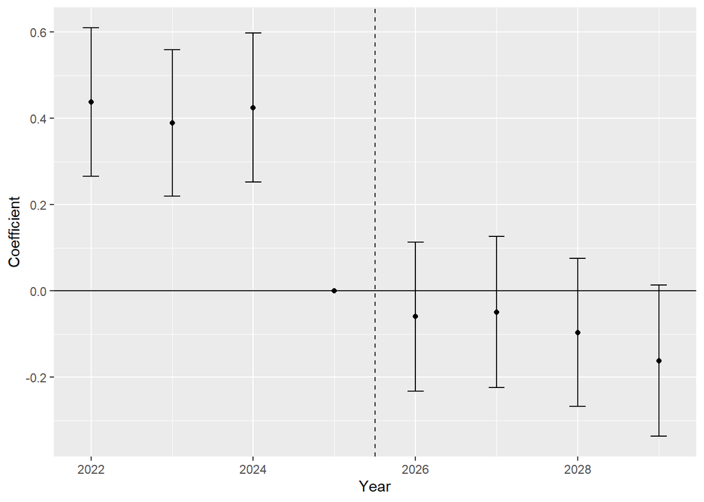

```r
es_coefs <- summary(reg_event_study)$coefficients

es_df <- data.frame(
  sd   = es_coefs[1:7, 2],
  mean = es_coefs[1:7, 1],
  year = c(2022, 2023, 2024, 2026, 2027, 2028, 2029))

# Add a zero for 2025 (the omitted reference year)
es_df[8, 1:2] <- 0
es_df[8, 3]   <- 2025

es_df <- es_df |>
  arrange(year) |>
  mutate(lb = mean - (1.96 * sd),
         ub = mean + (1.96 * sd))

ggplot(aes(x = year, y = mean), data = es_df) +
  geom_point() +
  geom_hline(yintercept = 0) +
  geom_vline(xintercept = 2025.5, linetype = "dashed") +
  ylab("Coefficient") + xlab("Year") +
  geom_errorbar(aes(ymin = lb, ymax = ub), width = 0.2,
                position = position_dodge(0.05))
```

Collapse the treated and control group to the state-year level and plot them both over time to see what’s going on here. Add a vertical line between 2025-26 by adding the line:

geom_vline(xintercept = 2025.5)

in ggplot

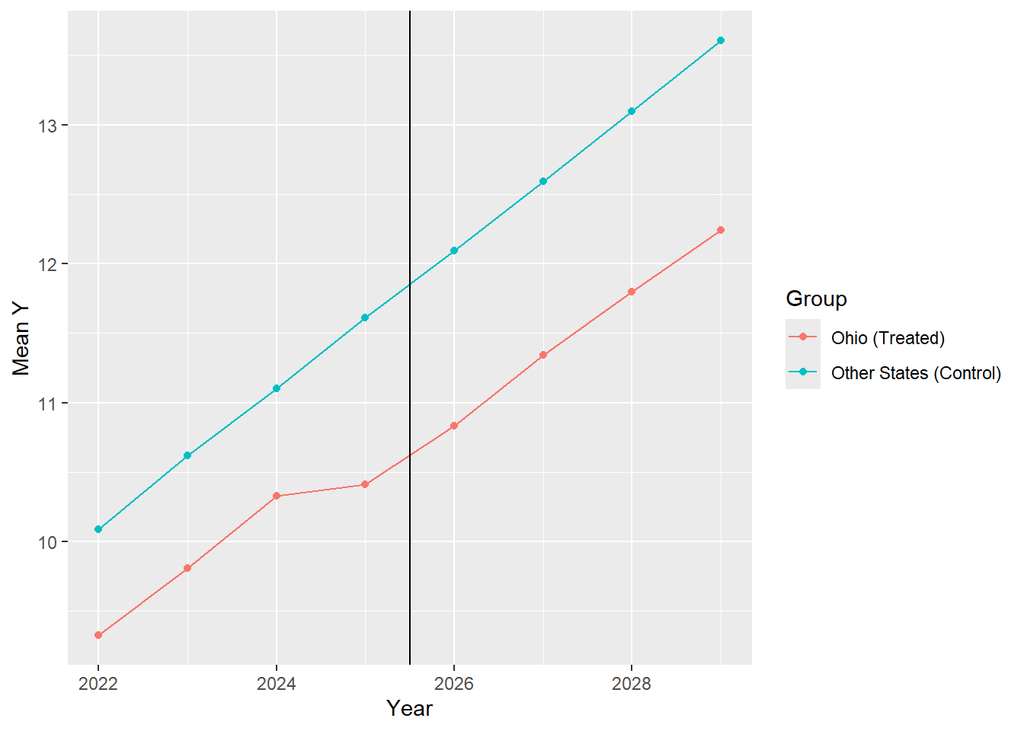

```r
trend_data <- ps_data |>
  group_by(state, year, Treat_s) |>
  summarise(Y = mean(Y, na.rm = TRUE), .groups = "drop") |>
  group_by(Treat_s, year) |>
  summarise(mean_Y = mean(Y, na.rm = TRUE), .groups = "drop") |>
  mutate(group = if_else(Treat_s, "Ohio (Treated)", "Other States (Control)"))

ggplot(aes(x = year, y = mean_Y, color = group), data = trend_data) +
  geom_line() +
  geom_point() +
  geom_vline(xintercept = 2025.5) +
  ylab("Mean Y") + xlab("Year") +
  labs(color = "Group")
```

What conclusions are you going to take the the governor?

**I would tell the governor that this data does not necessarily show a reduction in crime from the implementation of the policies. The event study table and the chart reflect a change in Ohio occurring about 2024 before the implementation of the governor’s policies, then after the change Ohio’s crime mostly tracks with the control states. The 2024 change could have come from changed behavior due to anticipation of the governor’s policies, or it could have come from an unrelated policy or event outside the scope and context of the data. It might be worth the governor’s time to investigate the cause of the crime reduction in 2024.**